# Clase 6

# Tarea 6.

# Metodos supervisados 2

Librerias

```r
library(caTools)
library(rpart)
library(dplyr)
```

```r
library(ggplot2)
#..........Librerias de los modelos
library(rpart)
library(randomForest)
library(neuralnet)
library(e1071)
library(nnet)
library(ROCR)
```

1. Desarolle el Analisis del Problema

```r
# Construya el análisis del problema


# Los datos se obtienen mediante el  parte oficial de tr?nsito que realiza la Direcci?n General de Polic?a de Tr?nsito al presentarse un accidente, los cuales ingresan a la base de datos de dos formas (hand held y papel). Debido a que parte de la labor principal de la Instituci?n es salvar vidas, y por los recursos limitados que existen, se trabaja solo con accidentes con heridos y/o fallecidos; y no se trabaja con accidentes que presentan solo da?os materiales. Adem?s, posteriormente inicia el proceso de limpieza, correcci?n de inconsistencias, validaci?n de algunas variables,  georeferenciaci?n de los accidentes, entre otros.


#Accidente con v?ctima se refiere cuando en el accidente de tr?nsito al menos uno de los participantes resulto: herido leve, grave o fallecido.

#Para m?s informaci?n revisar la metodolog?a del documento Memoria estad?stica de accidentes de tr?nsito con v?ctimas.Periodo 2012-2014.
```

Fuente del dataset: http://datosabiertos.csv.go.cr/dashboards/19683/accidentes/

1. Cargue el archivo nombre.csv en una variable

```r
accidentes <- read.csv(file = "temp_5571830814335439232.csv", header = TRUE, sep = ",", strip.white = TRUE, stringsAsFactors = TRUE,
                       colClasses = c("NULL","factor", "factor", "factor", "factor", "factor", "integer", "factor", "factor", "factor", "factor", "factor", "NULL", "NULL", "NULL"))

# Cambiamos los headers por unos más legibles
names(accidentes) <- c("rol", "lesion", "edad", "edad.quinquenal", "sexo", "anno", "mes", "dia", "provincia", "canton", "distrito")

# Cambiamos el tipo de lesion por Ileso o No Ileso
levels(accidentes$lesion) <- c("No Ileso", "No Ileso", "Ileso", "No Ileso")

# Cambiamos nombres de provincias por unos mas legibles
levels(accidentes$provincia) <- c("Alajuela", "Cartago", "Guanacaste", "Heredia", "Limon", "Puntarenas", "San Jose")

# Cambiamos nombres de rol por unos mas legibles
levels(accidentes$rol) <- c("Ciclista", "Conductor", "Dueno de propiedad", "Motociclista", "Otro", "Pasajero bicicleta", "Pasajero bus o microbus", "Pasajero carro", "Pasajero moto", "Peaton")

# Cambiamos nombres de dia por unos mas legibles
levels(accidentes$dia) <- c("Domingo", "Jueves", "Lunes", "Martes", "Miercoles", "Sabado", "Viernes")
accidentes$dia <- factor(accidentes$dia, order = TRUE,
                         levels = c("Lunes", "Martes", "Miercoles", "Jueves", "Viernes", "Sabado", "Domingo"))
```

2. Desarolle el Entendimiento de los Datos
3. Rol
4. Tipo de lesión
5. Edad
6. Sexo
7. Año
8. Mes
9. Día
10. Provincia
11. Cantón
12. Distrito
13. Utilizando barplot cree un grafico de los atributos del dataset, observe las correlaciones entre atributos

Parece que la variable rol es la más significativa para determinar si sale ileso o no de un accidente

```r
glimpse(accidentes)
```

```
## Observations: 158,399
## Variables: 11
## $ rol             <fct> Pasajero moto, Motociclista, Pasajero moto, Mo...
## $ lesion          <fct> No Ileso, No Ileso, No Ileso, Ileso, No Ileso,...
## $ edad            <fct> 15, 47, Desconocido, 20, Desconocido, 28, 30, ...
## $ edad.quinquenal <fct> De 15 a 19, De 45 a 49, Desconocida, De 20 a 2...
## $ sexo            <fct> Mujer, Hombre, Hombre, Hombre, Hombre, Mujer, ...
## $ anno            <int> 2015, 2015, 2013, 2013, 2013, 2013, 2013, 2013...
## $ mes             <fct> Enero, Enero, Marzo, Marzo, Marzo, Febrero, Fe...
## $ dia             <ord> Domingo, Domingo, Domingo, Domingo, Domingo, M...
## $ provincia       <fct> Puntarenas, Puntarenas, San Jose, San Jose, Sa...
## $ canton          <fct> Coto Brus, Coto Brus, San JosÃ©, San JosÃ©, Sa...
## $ distrito        <fct> Sabalito, Sabalito, Hospital, Hospital, Hospit...
```

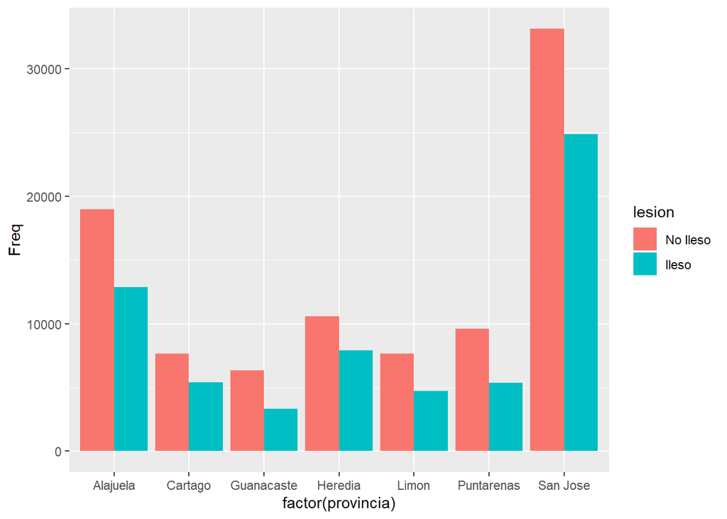

```r
tbl <- with(accidentes, table(lesion, provincia))
ggplot(as.data.frame(tbl), aes(factor(provincia), Freq, fill = lesion)) +
  geom_col(position = 'dodge')
```

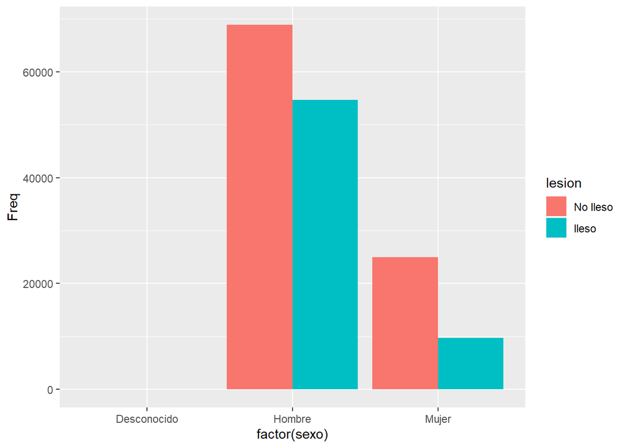

```r
tbl <- with(accidentes, table(lesion, sexo))
ggplot(as.data.frame(tbl), aes(factor(sexo), Freq, fill = lesion)) +
  geom_col(position = 'dodge')
```

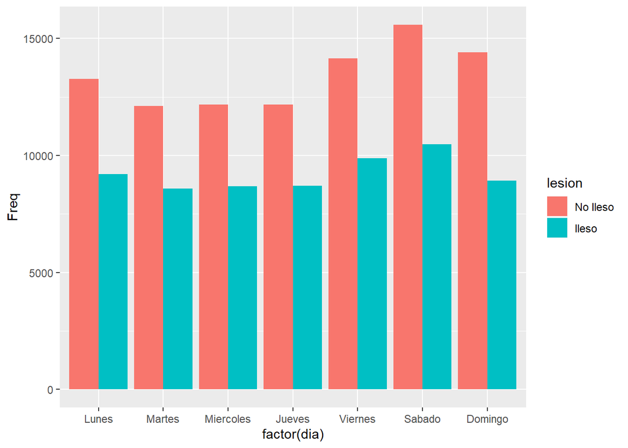

```r
tbl <- with(accidentes, table(lesion, dia))
ggplot(as.data.frame(tbl), aes(factor(dia), Freq, fill = lesion)) +
  geom_col(position = 'dodge')
```

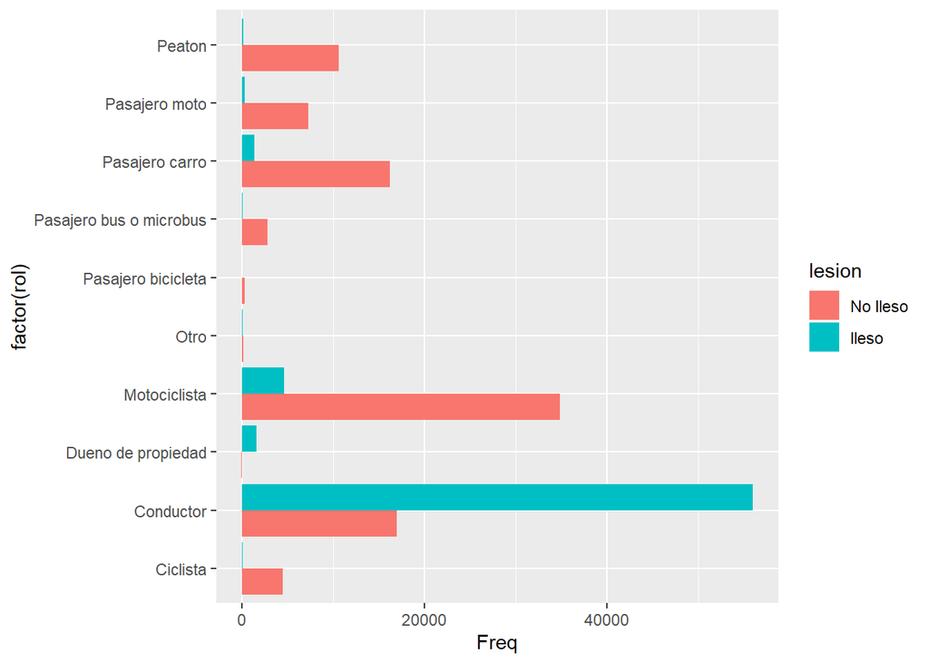

```r
tbl <- with(accidentes, table(lesion, rol))
ggplot(as.data.frame(tbl), aes(factor(rol), Freq, fill = lesion)) +
  geom_col(position = 'dodge') +
  coord_flip()
```

4. Realice al menos 5 modelos de los observados en clase

```r
set.seed(777)
splt <- sample.split(accidentes$lesion, SplitRatio = 0.7)
accidentes.entrenamiento <- accidentes[splt,]
accidentes.prueba <- accidentes[!splt,]

accidentes.small <- accidentes[1:10000,]
splt2 <- sample.split(accidentes.small$lesion, SplitRatio = 0.7)
accidentes.small.entrenamiento <- accidentes.small[splt2,]
accidentes.small.prueba <- accidentes.small[!splt2,]
```

```r
modelo.arbol <- rpart(lesion ~ rol + edad.quinquenal + sexo, data = accidentes.entrenamiento, method =  'class')
modelo.bosque <- randomForest(lesion ~ rol + edad.quinquenal + sexo, data = accidentes.entrenamiento)
modelo.regresion <- stats::glm(lesion ~ rol + edad.quinquenal + sexo, data = accidentes.entrenamiento, family = binomial)
modelo.svm <- svm(lesion  ~  rol + edad.quinquenal + sexo, data = accidentes.small.entrenamiento, kernel='linear',cross=2, scale=FALSE)
```

```r
# Modelo de Red Neuronal
accidentes.entrenamiento <- cbind(accidentes.entrenamiento, class.ind(accidentes.entrenamiento$lesion))
accidentes.entrenamiento <- cbind(accidentes.entrenamiento, class.ind(accidentes.entrenamiento$rol))
names(accidentes.entrenamiento)[12:23] <-
  c("No.Ileso","Ileso","Ciclista","Conductor","Duenno.de.propiedad","Motociclista","Otro",
    "Pasajero.bicicleta","Pasajero.bus.o.microbus","Pasajero.carro","Pasajero.moto","Peaton")

modelo.neural <- neuralnet(
  Ileso ~ Ciclista+Conductor+Duenno.de.propiedad+Motociclista+Otro+Pasajero.bicicleta+Pasajero.bus.o.microbus+Pasajero.carro+Pasajero.moto+Peaton,
  data=accidentes.entrenamiento,
  hidden=3
)
```

5. Evaluacion de los modelos

```r
# Evaluacion de Arbol de desicion
modelo.arbol.predicciones <- predict(modelo.arbol, newdata = accidentes.prueba, type = 'class')
modelo.arbol.evaluacion <- table(accidentes.prueba$lesion, modelo.arbol.predicciones)
modelo.arbol.performance <- performance(ROCR::prediction(c(modelo.arbol.predicciones), c(accidentes.prueba$lesion)), measure = "auc")@y.values
print(modelo.arbol.evaluacion)
```

```
##           modelo.arbol.predicciones
##            No Ileso Ileso
##   No Ileso    23107  5068
##   Ileso        2037 17308
```

```r
print(modelo.arbol.performance)
```

```
## [[1]]
## [1] 0.8574128
```

```r
# Curva ROC
prediccionesROC = ROCR::prediction(c(modelo.arbol.predicciones), c(accidentes.prueba$lesion))
as.numeric(performance(prediccionesROC, "auc")@y.values)
```

```
## [1] 0.8574128
```

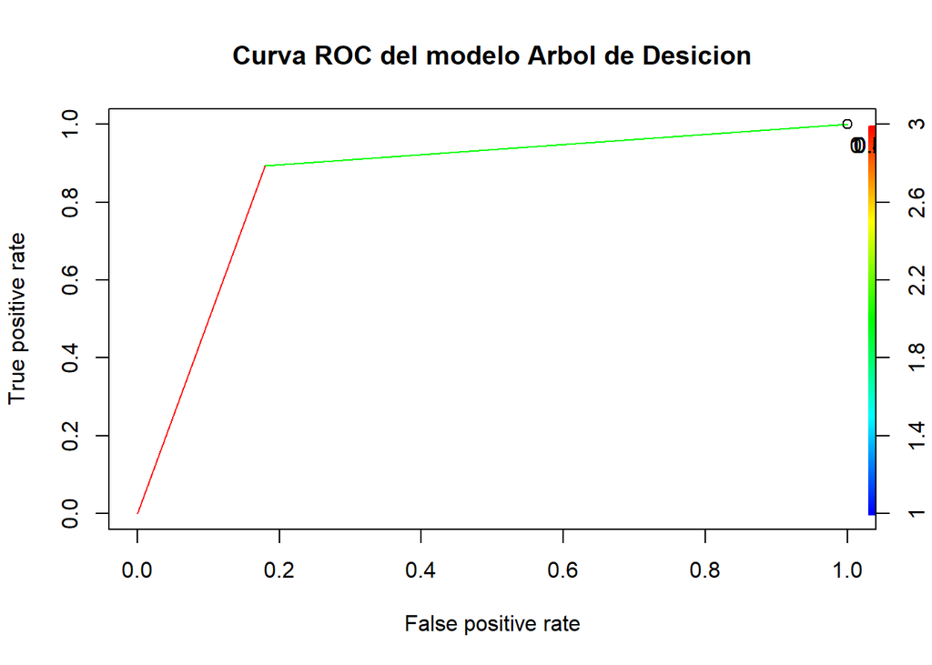

```r
plot(performance(prediccionesROC, "tpr", "fpr"),
colorize = T,
print.cutoffs.at = seq(0,1,by = 0.1),
text.adj = c(-0.2,1.7),
main = 'Curva ROC del modelo Arbol de Desicion')
```

```r
# Evaluamos las predicciones del random forest
modelo.bosque.predicciones <- predict(modelo.bosque, newdata = accidentes.prueba, type = 'class')
modelo.bosque.evaluacion <- table(accidentes.prueba$lesion, modelo.bosque.predicciones)
modelo.bosque.performance <- performance(ROCR::prediction(c(modelo.bosque.predicciones), c(accidentes.prueba$lesion)), measure = "auc")@y.values
print(modelo.bosque.evaluacion)
```

```
##           modelo.bosque.predicciones
##            No Ileso Ileso
##   No Ileso    23107  5068
##   Ileso        2035 17310
```

```r
print(modelo.bosque.performance)
```

```
## [[1]]
## [1] 0.8574645
```

```r
# Curva ROC
prediccionesROC = ROCR::prediction(c(modelo.bosque.predicciones), c(accidentes.prueba$lesion))
as.numeric(performance(prediccionesROC, "auc")@y.values)
```

```
## [1] 0.8574645
```

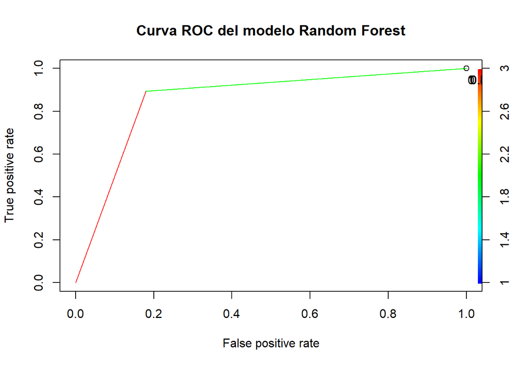

```r
plot(performance(prediccionesROC, "tpr", "fpr"),
colorize = T,
print.cutoffs.at = seq(0,1,by = 0.1),
text.adj = c(-0.2,1.7),
main = 'Curva ROC del modelo Random Forest')
```

```r
# Evaluamos las predicciones de la regresion logistica
modelo.regresion.predicciones <- predict(modelo.regresion, newdata = accidentes.prueba, type = 'response')
modelo.regresion.evaluacion <- table(accidentes.prueba$lesion, modelo.regresion.predicciones >= 0.7)
modelo.regresion.performance <- performance(ROCR::prediction(c(modelo.regresion.predicciones), c(accidentes.prueba$lesion)), measure = "auc")@y.values
print(modelo.regresion.evaluacion)
```

```
##
##            FALSE  TRUE
##   No Ileso 23730  4445
##   Ileso     3336 16009
```

```r
print(modelo.regresion.performance)
```

```
## [[1]]
## [1] 0.8834186
```

```r
# Curva ROC
prediccionesROC = ROCR::prediction(c(modelo.regresion.predicciones), c(accidentes.prueba$lesion))
as.numeric(performance(prediccionesROC, "auc")@y.values)
```

```
## [1] 0.8834186
```

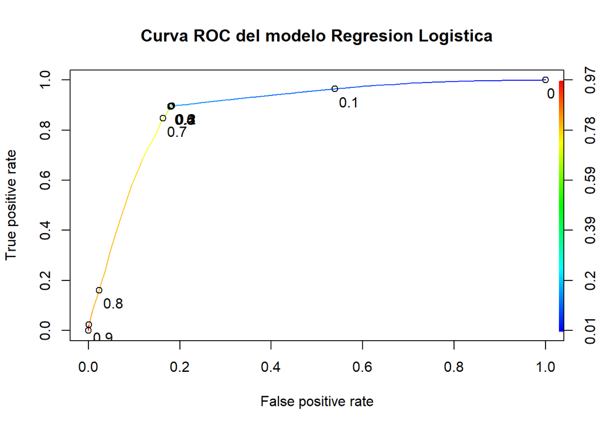

```r
plot(performance(prediccionesROC, "tpr", "fpr"),
colorize = T,
print.cutoffs.at = seq(0,1,by = 0.1),
text.adj = c(-0.2,1.7),
main = 'Curva ROC del modelo Regresion Logistica')
```

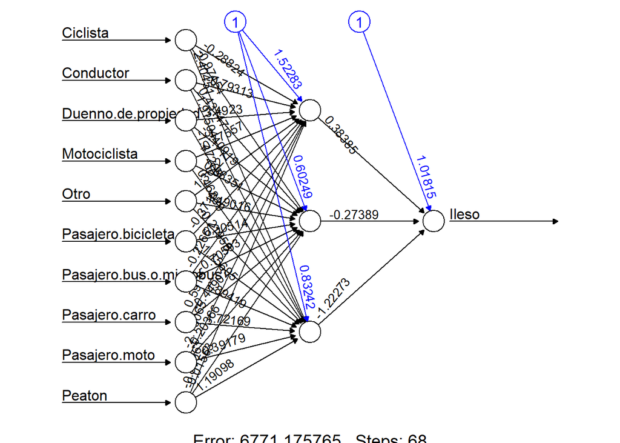

```r
# Evaluamos las predicciones de la Red Neuronal
accidentes.prueba <- cbind(accidentes.prueba, class.ind(accidentes.prueba$lesion))
accidentes.prueba <- cbind(accidentes.prueba, class.ind(accidentes.prueba$rol))
names(accidentes.prueba)[12:23] <-
  c("No.Ileso","Ileso","Ciclista","Conductor","Duenno.de.propiedad","Motociclista","Otro",
    "Pasajero.bicicleta","Pasajero.bus.o.microbus","Pasajero.carro","Pasajero.moto","Peaton")

plot(modelo.neural,rep="best")
```

```r
mp <- as.matrix(sapply(accidentes.prueba[,12:23], as.numeric))
modelo.neural.predicciones <- neuralnet::compute(modelo.neural, mp)

results <- data.frame(actual = mp, prediction = modelo.neural.predicciones$net.result)
#results

modelo.neural.evaluacion <- table(accidentes.prueba$lesion, modelo.neural.predicciones$net.result >= 0.7)
modelo.neural.performance <- performance(ROCR::prediction(c(modelo.neural.predicciones$net.result), c(accidentes.prueba$lesion)), measure = "auc")@y.values
print(modelo.neural.evaluacion)
```

```
##
##            FALSE  TRUE
##   No Ileso 23107  5068
##   Ileso     2037 17308
```

```r
print(modelo.neural.performance)
```

```
## [[1]]
## [1] 0.872027
```

```r
# Curva ROC
prediccionesROC = ROCR::prediction(c(modelo.neural.predicciones$net.result), c(accidentes.prueba$lesion))
as.numeric(performance(prediccionesROC, "auc")@y.values)
```

```
## [1] 0.872027
```

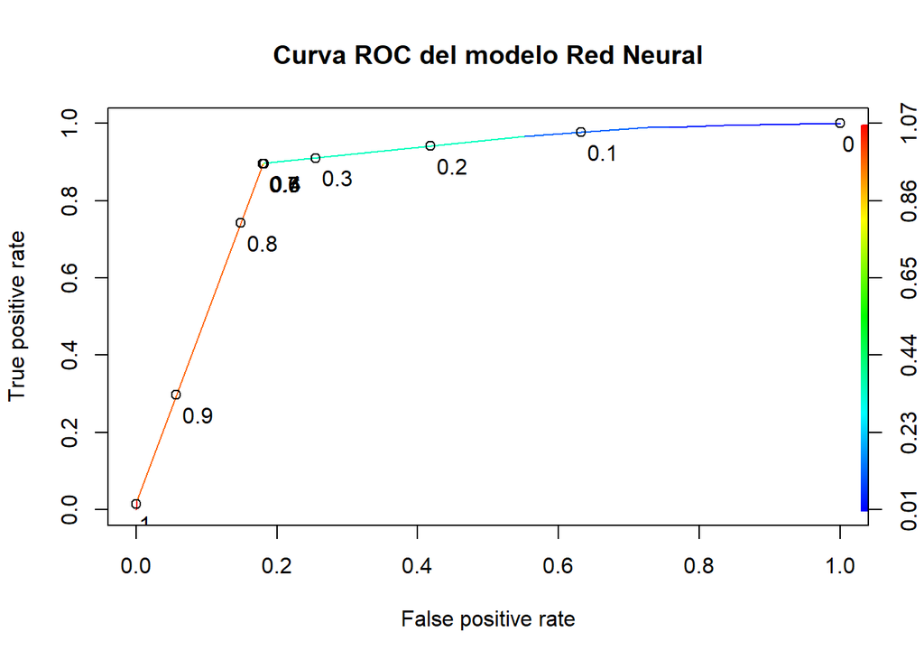

```r
plot(performance(prediccionesROC, "tpr", "fpr"),
colorize = T,
print.cutoffs.at = seq(0,1,by = 0.1),
text.adj = c(-0.2,1.7),
main = 'Curva ROC del modelo Red Neural')
```

```r
# Evaluamos las predicciones de SVM
modelo.svm.predict <- predict(modelo.svm, newdata = accidentes.small.prueba)
modelo.svm.evaluacion <- table(accidentes.small.prueba$lesion, modelo.svm.predict)
modelo.svm.performance <- performance(ROCR::prediction(c(modelo.svm.predict), c(accidentes.small.prueba$lesion)), measure = "auc")@y.values
print(modelo.neural.evaluacion)
```

```
##
##            FALSE  TRUE
##   No Ileso 23107  5068
##   Ileso     2037 17308
```

```r
print(modelo.svm.performance)
```

```
## [[1]]
## [1] 0.8680409
```

```r
# Curva ROC
prediccionesROC = ROCR::prediction(c(modelo.svm.predict), c(accidentes.small.prueba$lesion))
as.numeric(performance(prediccionesROC, "auc")@y.values)
```

```
## [1] 0.8680409
```

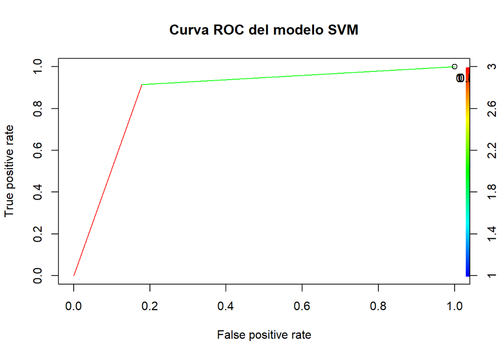

```r
plot(performance(prediccionesROC, "tpr", "fpr"),
colorize = T,
print.cutoffs.at = seq(0,1,by = 0.1),
text.adj = c(-0.2,1.7),
main = 'Curva ROC del modelo SVM')
```

6. Desarolle al menos 5 conclusiones sobre las clasificaciones de los modelos
- El modelo de Regresion Logistica nos ha dado los mejores resultados, la curva ROC destaca de las demás y se nota que tiene mejor rendimiento.
- El Arbol de desicion y el Random Forest nos dan resultados muy similares, se puede notar al ver los graficos ROC de ambas son muy similares. Se podría mejorar el algoritmo de Random Forest aplicando un poco de tuning pero no se obtuvo resultados significativos.
- La red neuronal no es el mejor modelo para este caso, al tratar de agregar más inputs se hace inmanejable y dura mucho en correr el modelo.
- Parece que la variable de rol es la que más afecta los resultados, ya que las demás variables no muentras tanta diferencia entre si.
- Se recomienda utilizar un dataset con más columnas disponible en el sitio del COSEVI, en la que es posible existan variables más significativas.